# Introduction au langage de programmation R

**Astuce**

Pour tous ces paramètres, un argument normal peut être spécifie (‘*red*’ pour la couleur, *2* pour la taille etc.), mais il est aussi possible de mettre le nom d’une autre variable de manière à intégrer une **information supplémentaire** au graphique. Ce peut être une variable catégorielle pour la couleur, une variable numérique pour la taille des points etc.

- **Personnalisation basique**

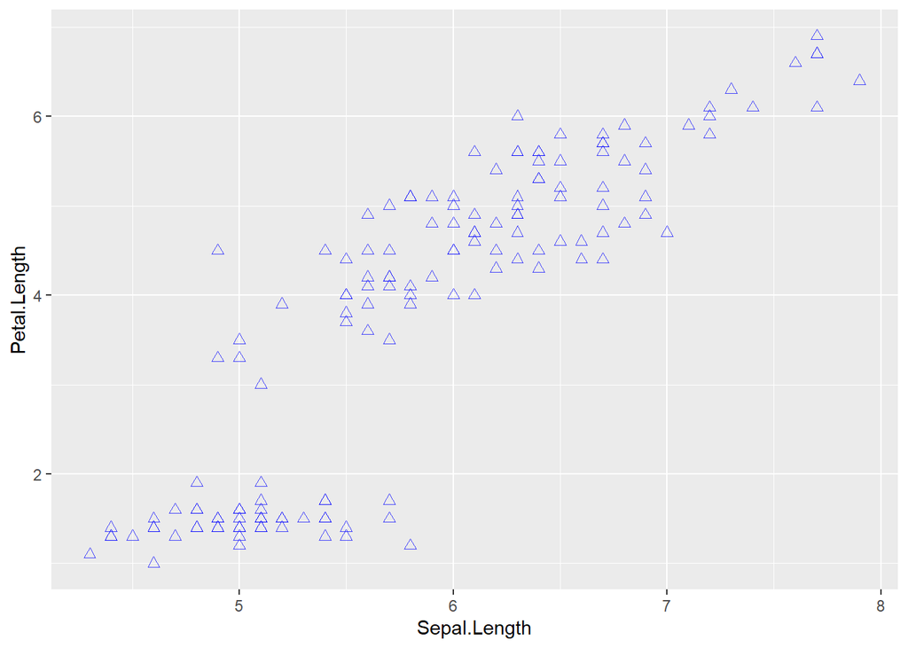

```r
# Graphique en nuage de points personnalisé
ggplot(data = iris) +
  geom_point(mapping = aes(x = Sepal.Length, y = Petal.Length),
             color = "blue", size = 2, alpha = 0.7, shape = 2)
```

Il existe sur R deux manières de renseigner les couleurs : soit en spécifiant la couleur **par son nom** (*exemple : “brown”*), soit en la spécifiant par **son code Hex** (*exemple : “#dd9933”*). Il s’agit d’une chaîne de 6 caractères (chiffres et/ou lettres) qui correspond à une couleur que l’on peut [créer soi-même](https://www.color-hex.com/), sur le tableau ci-dessous on retrouve une palette de couleurs déjà créées pour lesquelles on a le code HEX.

Les formes des points peuvent aussi être spécifiées de deux manières : soit **par un chiffre** (*exemple : 18*) qui correspond à une forme déjà définie visible dans le tableau ci-dessous, soit **par un caractère** - un seul (*exemple : “B”*), qui sera utilisé comme forme de point.

Les couleurs

Les formes

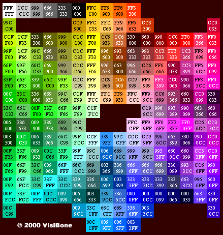

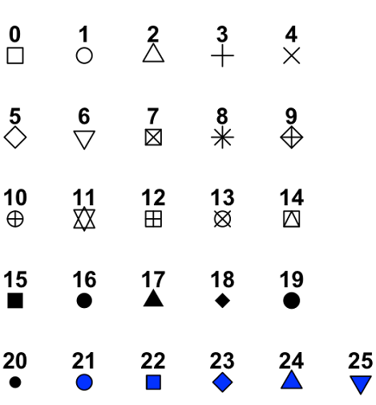

[pour plus d’informations](http://www.stat.columbia.edu/~tzheng/files/Rcolors.pdf)

[pour plus d’informations](https://www.datanovia.com/en/fr/blog/ggplot-forme-des-points-meilleures-reference/)

- **Personnalisation en fonction d’autres variables**

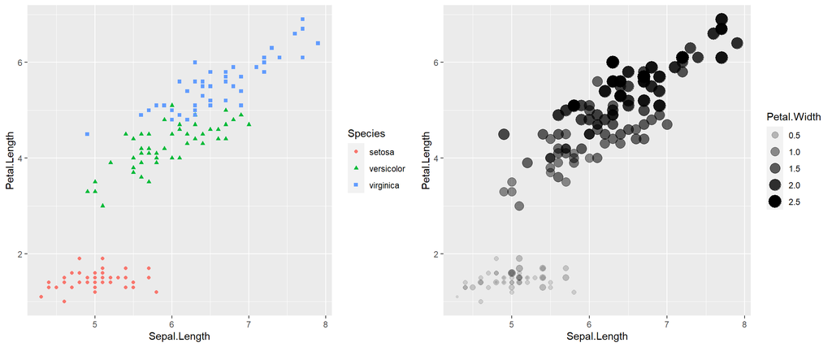

```r
# Forme et couleur selon l'espèce de fleur
ggplot(data = iris) +
  geom_point(mapping = aes(x = Sepal.Length, y = Petal.Length, color = Species, shape = Species))

# Taille et opacité selon la largeur du pétale
ggplot(data = iris) +
  geom_point(mapping = aes(x = Sepal.Length, y = Petal.Length, alpha = Petal.Width, size = Petal.Width))
```

Sur les graphiques ci-dessus on a défini les paramètres visuels des points selon d’autres variables du dataframe ‘iris’. Comme il s’agit de variables, leur spécification se fait **à l’intérieur de la parenthèse `aes()`** qui pour rappel, correspond aux propriétés esthétiques.

- **Les titres**

Par défaut le **nom des variables** sera mis comme *label* aux axes des abscisse et des ordonnées, mais il est possible de les modifier ou d’ajouter des titres au graphique grâce à la fonction `labs()`, qui peut être ajoutée aux paramètres actuels par un `+`.

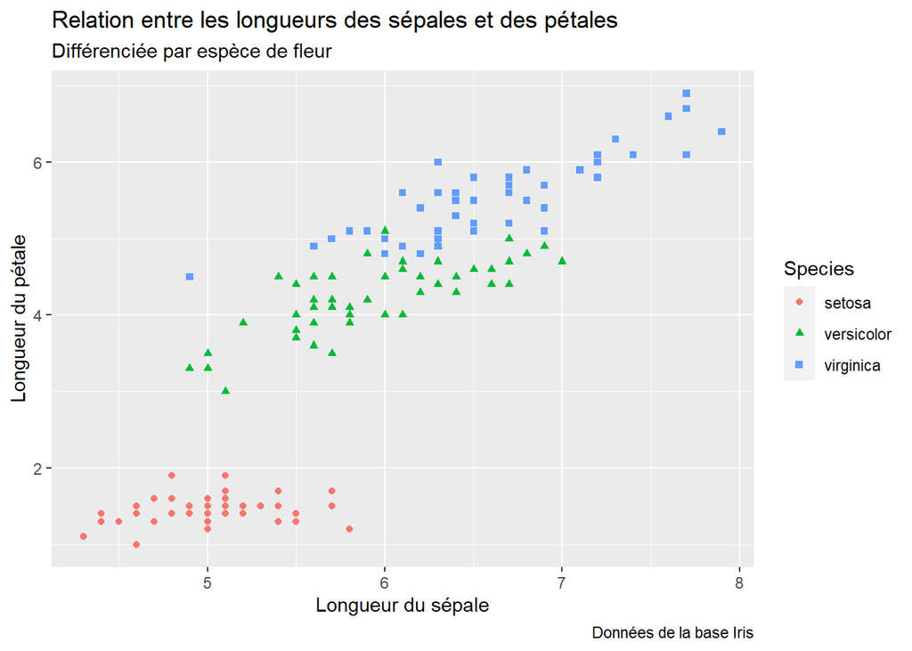

```r
# Titres du graphique
ggplot(data = iris) +
  geom_point(mapping = aes(x = Sepal.Length, y = Petal.Length, color = Species, shape = Species)) +
  labs(title = "Relation entre les longueurs des sépales et des pétales",
       subtitle = "Différenciée par espèce de fleur",
       caption = "Données de la base Iris",
       x = "Longueur du sépale",
       y = "Longueur du pétale")
```

Pour n’avoir aucun titre sur le graphique il suffit de spécifier `x` et `y = NULL` dans la fonction `labs()` :

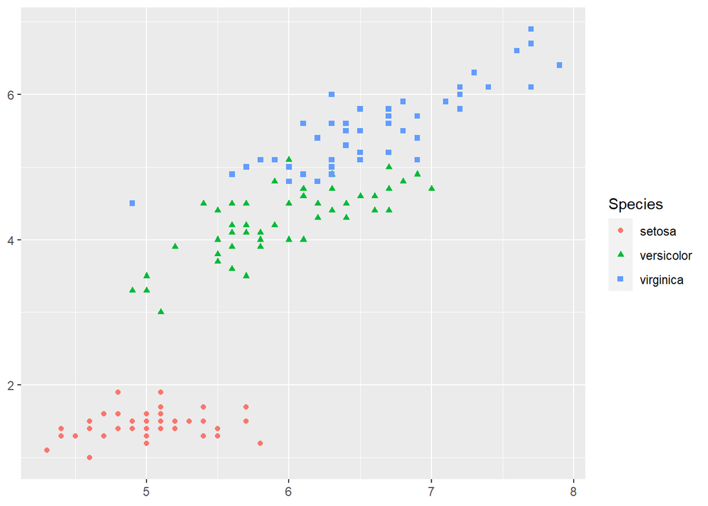

```r
# Aucun titre
ggplot(data = iris) +
  geom_point(mapping = aes(x = Sepal.Length, y = Petal.Length, color = Species, shape = Species)) +
  labs(x = NULL,
       y = NULL)
```

- **Les thèmes**

Il est possible de modifier **l’apparence du graphique** (taille, polices et couleur des titres, fond du graphique, quadrillages etc.) de deux manières :

- **manuellement** en spécifiant les éléments à modifier dans la fonction `theme()` qui peut s’ajouter à la suite des paramètres existant du graphique par un `+`
- **automatiquement** en utilisant des thèmes déjà définis dans *ggplot* grâce à la fonction `theme_**()`

La liste complète des thèmes disponibles se trouve au lien [ggplot2.tidyverse.org](https://ggplot2.tidyverse.org/reference/ggtheme.html), voilà quelques exemples de thèmes appliqués à notre graphique en construction :

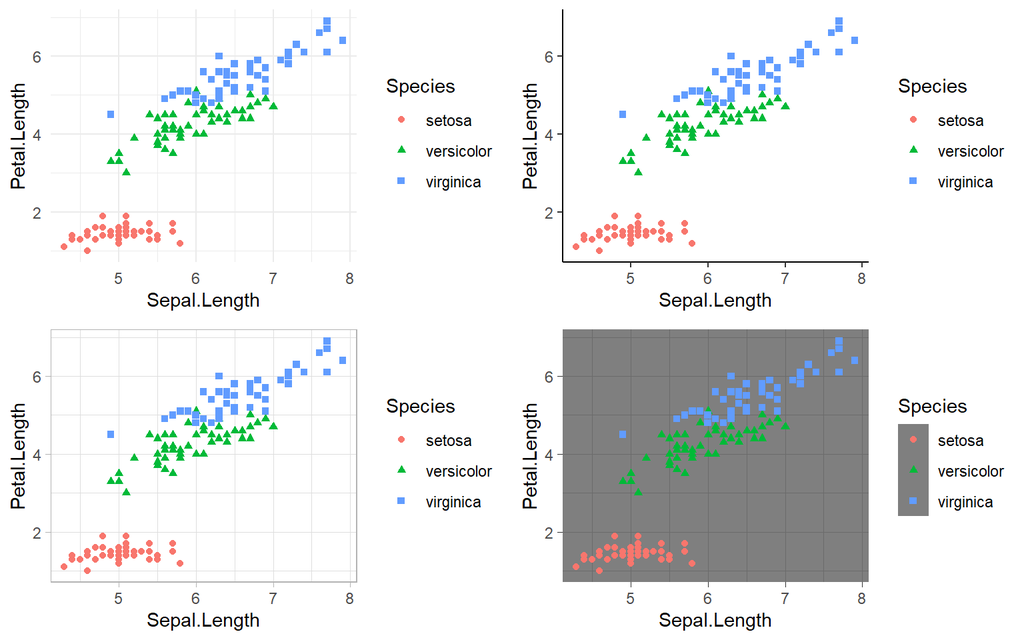

```r
# Thèmes
ggplot(data = iris) +
  geom_point(mapping = aes(x = Sepal.Length, y = Petal.Length, color = Species, shape = Species)) +
  theme_minimal()

ggplot(data = iris) +
  geom_point(mapping = aes(x = Sepal.Length, y = Petal.Length, color = Species, shape = Species)) +
  theme_classic()

ggplot(data = iris) +
  geom_point(mapping = aes(x = Sepal.Length, y = Petal.Length, color = Species, shape = Species)) +
  theme_light()

ggplot(data = iris) +
  geom_point(mapping = aes(x = Sepal.Length, y = Petal.Length, color = Species, shape = Species)) +
  theme_dark()
```

D’autres encore sont disponibles dans le package `ggthemes`, l’utilisation est la même que pour les thèmes de `ggplot2`, après avoir installé le package (*install.package(“ggthemes”)*). La liste des thèmes disponibles dans ce package se trouve [ici](https://yutannihilation.github.io/allYourFigureAreBelongToUs/ggthemes/).

- **La légende**

Les éléments de légende peuvent être modifiés comme arguments de la fonction `theme()` que nous venons de voir, il est possible de modifier la position, le titre, les textes, les couleurs de la légende. Quelques exemples :

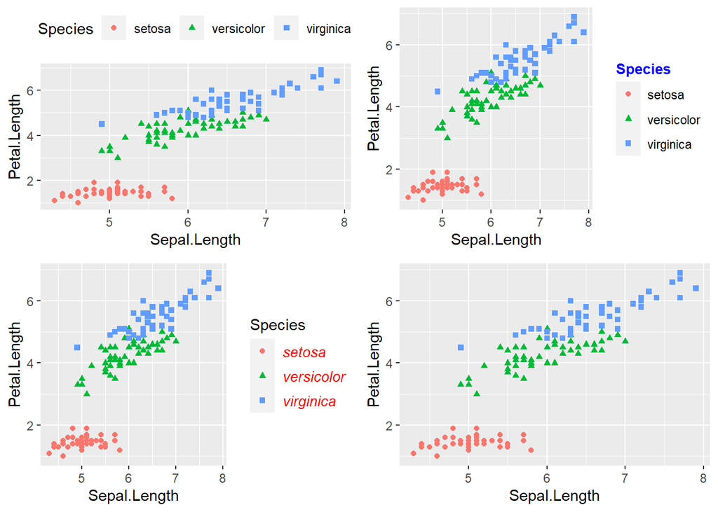

```r
# Position
ggplot(data = iris) +
  geom_point(mapping = aes(x = Sepal.Length, y = Petal.Length, color = Species, shape = Species)) +
  theme(legend.position = "top")  #top, bottom, left or right

# Paramétrage du titre de la légende
ggplot(data = iris) +
  geom_point(mapping = aes(x = Sepal.Length, y = Petal.Length, color = Species, shape = Species)) +
  theme(legend.title = element_text(color="blue", size=10,
                                      face="bold"))
# Paramétrage du texte de la légende
ggplot(data = iris) +
  geom_point(mapping = aes(x = Sepal.Length, y = Petal.Length, color = Species, shape = Species)) +
  theme(legend.text = element_text(colour="red", size=10,
                                     face="italic"))

# Supprimer la légende
ggplot(data = iris) +
  geom_point(mapping = aes(x = Sepal.Length, y = Petal.Length, color = Species, shape = Species)) +
  theme(legend.position = "none")
```

**Astuce**

Bien que l’apparence puisse être définie par la fonction `theme_**()`, il est possible de modifier les paramètres du thème existant en ajoutant **après** celle-ci la fonction `theme()` - dans laquelle il est par exemple possible de modifier les éléments de la légende, comme ci-dessus.

- **Les facettes**

Lorsque l’on veut représenter graphiquement les données par *groupe* on peut le faire de différentes manières :

- en les **colorant** selon le groupe (comme vu précédemment avec l’**espèce** de fleur)
- en les **séparant** en sous-graphiques selon le groupe

Dans le package `ggplot` ce sont les fonctions `facet_grid()` et `facet_wrap()` qui permettent de créer des ‘facettes’ à un graphique, selon une variable catégorielle (un groupe).

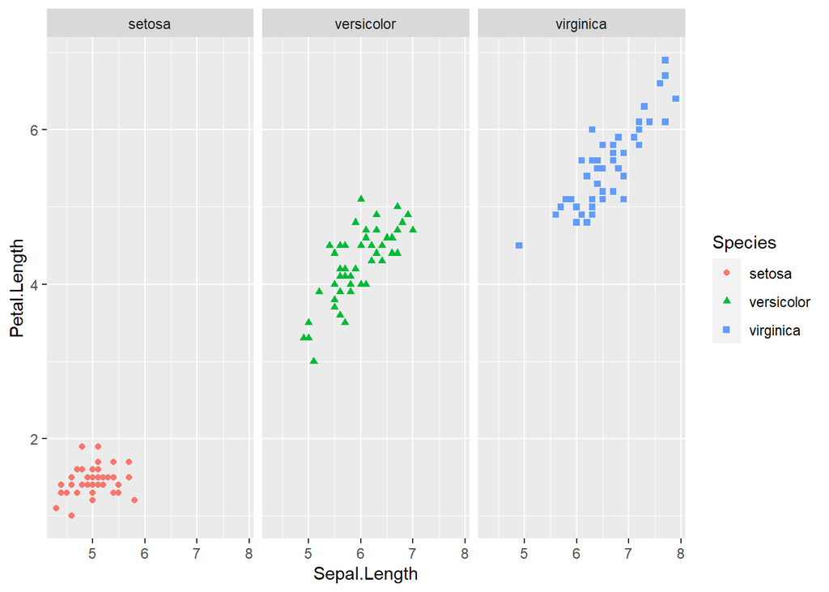

```r
# Facettes sur une seule ligne avec facet_grid
ggplot(data = iris) +
  geom_point(mapping = aes(x = Sepal.Length, y = Petal.Length, color = Species, shape = Species)) +
  facet_grid(cols = vars(Species))
```

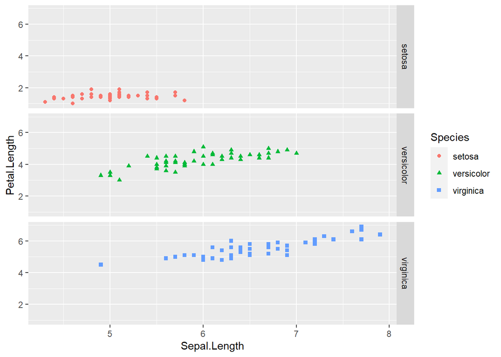

```r
# Facettes sur une seule colonne avec facet_grid
ggplot(data = iris) +
  geom_point(mapping = aes(x = Sepal.Length, y = Petal.Length, color = Species, shape = Species)) +
  facet_grid(rows = vars(Species))
```

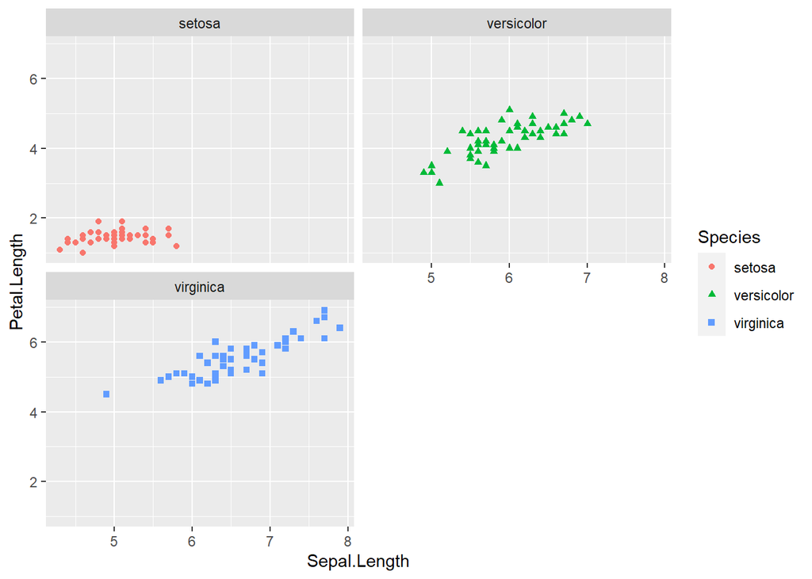

```r
# Facettes en matrice avec facet_wrap
ggplot(data = iris) +
  geom_point(mapping = aes(x = Sepal.Length, y = Petal.Length, color = Species, shape = Species)) +
  facet_wrap(vars(Species), ncol = 2, nrow = 2)
```

- **Les limites**

La fonction `lims()` permet de spécifier soi-même les **limites du graphique**, de la manière suivante : `c(min, max)`.

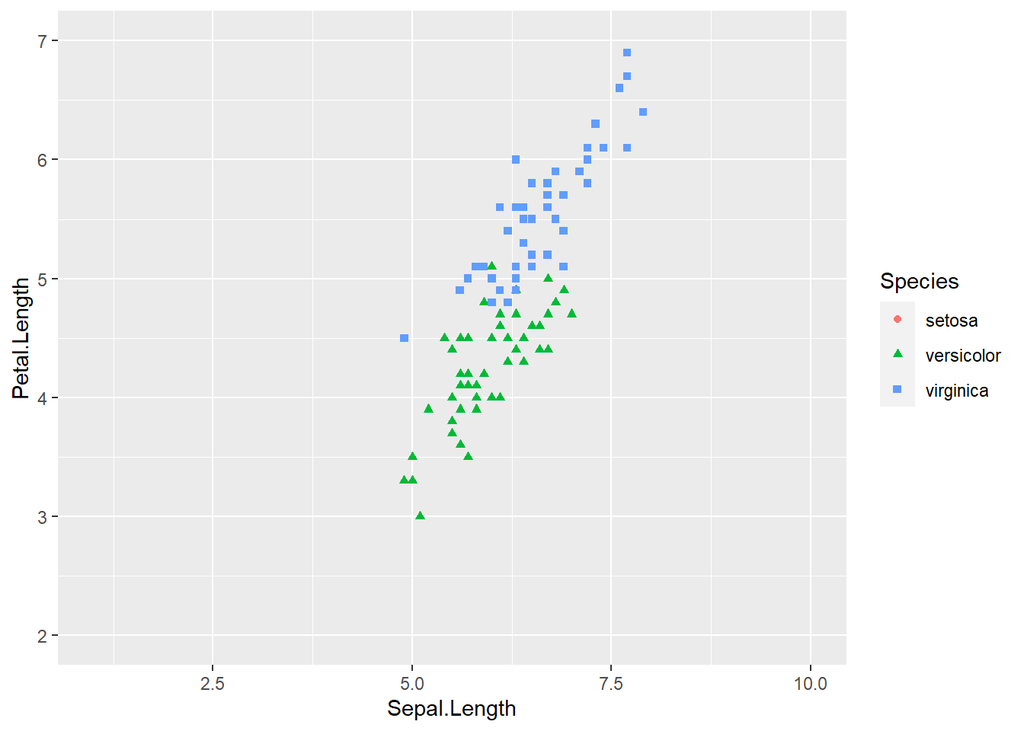

```r
# Modification des limites
ggplot(data = iris) +
  geom_point(mapping = aes(x = Sepal.Length, y = Petal.Length, color = Species, shape = Species)) +
  lims(x = c(1,10), y = c(2,7))
```

### Communiquer

RMD

- themes possibles par défaut : texte https://www.datadreaming.org/post/r-markdown-theme-gallery/
- themes ds autres packages pour du texte html https://bookdown.org/yihui/rmarkdown/html-document.html#appearance-and-style
- themes possibles par défaut : code https://eranraviv.com/syntax-highlighting-style-in-rmarkdown/

# Bibliographie

- http://www.sthda.com/english/wiki/ggplot2-essentials
- https://r4ds.had.co.nz/data-visualisation.html
- file:///C:/Users/diane/Desktop/Ordi%20perso/Aide%20R/tutoriales_intro_DS-master/tt_06_ggplot2_v6.html
- file:///C:/Users/diane/Desktop/Ordi%20perso/Aide%20R/tutoriales_intro_DS-master/tt_07_Rmarkdown_v2.html#6_a%C3%BAn_m%C3%A1s_cosas
- file:///C:/Users/diane/Desktop/Ordi%20perso/Aide%20R/tutoriales_intro_DS-master/tt_08_tablas_v1.html